# Pima Indians Diabetes

#### Using Python and some basic stats, we will be predicting a person has diabetes or not based on the information such as glucose, blood pressure, BMI etc.

### Importing the libraries pandas, numpy, matplotlib, seaborn, sklearn, train_test_split

```python
import pandas as pd
import numpy as np
import seaborn as sns
import matplotlib.pyplot as plt
from sklearn.model_selection import train_test_split
```

### Importing the data set

```python
df = pd.read_csv('diabetes.csv')
print(df.head())
```

```
   Pregnancies  Glucose  BloodPressure  SkinThickness  Insulin   BMI  \
0            6      148             72             35        0  33.6
1            1       85             66             29        0  26.6
2            8      183             64              0        0  23.3
3            1       89             66             23       94  28.1
4            0      137             40             35      168  43.1

   DiabetesPedigreeFunction  Age  Outcome
0                     0.627   50        1
1                     0.351   31        0
2                     0.672   32        1
3                     0.167   21        0
4                     2.288   33        1
```

### Respective column's name are the features to help us predict whether a person is diabetic or not

Pregnancies: Number of times pregnant

Glucose: Plasma glucose concentration over 2 hours in an oral glucose tolerance test

BSkinThickness: Triceps skin fold thickness (mm)

Insulin: 2-Hour serum insulin (mu U/ml

BMI: Body mass index (weight in kg/(height in m)2)

DiabetesPedigreeFunction: Diabetes pedigree function (a function which scores likelihood of diabetes based on family history)

Age: Age in years

Outcome: Class variable (0 if non-diabetic, 1 if diabetic)

### Data Description

```python
df.head(6)
```

|  | Pregnancies | Glucose | BloodPressure | SkinThickness | Insulin | BMI | DiabetesPedigreeFunction | Age | Outcome |
| --- | --- | --- | --- | --- | --- | --- | --- | --- | --- |
| 0 | 6 | 148 | 72 | 35 | 0 | 33.6 | 0.627 | 50 | 1 |
| 1 | 1 | 85 | 66 | 29 | 0 | 26.6 | 0.351 | 31 | 0 |
| 2 | 8 | 183 | 64 | 0 | 0 | 23.3 | 0.672 | 32 | 1 |
| 3 | 1 | 89 | 66 | 23 | 94 | 28.1 | 0.167 | 21 | 0 |
| 4 | 0 | 137 | 40 | 35 | 168 | 43.1 | 2.288 | 33 | 1 |
| 5 | 5 | 116 | 74 | 0 | 0 | 25.6 | 0.201 | 30 | 0 |

```python
df.tail(5)
```

|  | Pregnancies | Glucose | BloodPressure | SkinThickness | Insulin | BMI | DiabetesPedigreeFunction | Age | Outcome |
| --- | --- | --- | --- | --- | --- | --- | --- | --- | --- |
| 763 | 10 | 101 | 76 | 48 | 180 | 32.9 | 0.171 | 63 | 0 |
| 764 | 2 | 122 | 70 | 27 | 0 | 36.8 | 0.340 | 27 | 0 |
| 765 | 5 | 121 | 72 | 23 | 112 | 26.2 | 0.245 | 30 | 0 |
| 766 | 1 | 126 | 60 | 0 | 0 | 30.1 | 0.349 | 47 | 1 |
| 767 | 1 | 93 | 70 | 31 | 0 | 30.4 | 0.315 | 23 | 0 |

```python
df.info() # verify whether the dataset is clean or not
```

```
<class 'pandas.core.frame.DataFrame'>
RangeIndex: 768 entries, 0 to 767
Data columns (total 9 columns):
 #   Column                    Non-Null Count  Dtype
---  ------                    --------------  -----
 0   Pregnancies               768 non-null    int64
 1   Glucose                   768 non-null    int64
 2   BloodPressure             768 non-null    int64
 3   SkinThickness             768 non-null    int64
 4   Insulin                   768 non-null    int64
 5   BMI                       768 non-null    float64
 6   DiabetesPedigreeFunction  768 non-null    float64
 7   Age                       768 non-null    int64
 8   Outcome                   768 non-null    int64
dtypes: float64(2), int64(7)
memory usage: 54.1 KB
```

### Checking if all the columns contain numric value only

```python
df.applymap(np.isreal)
```

|  | Pregnancies | Glucose | BloodPressure | SkinThickness | Insulin | BMI | DiabetesPedigreeFunction | Age | Outcome |
| --- | --- | --- | --- | --- | --- | --- | --- | --- | --- |
| 0 | True | True | True | True | True | True | True | True | True |
| 1 | True | True | True | True | True | True | True | True | True |
| 2 | True | True | True | True | True | True | True | True | True |
| 3 | True | True | True | True | True | True | True | True | True |
| 4 | True | True | True | True | True | True | True | True | True |
| ... | ... | ... | ... | ... | ... | ... | ... | ... | ... |
| 763 | True | True | True | True | True | True | True | True | True |
| 764 | True | True | True | True | True | True | True | True | True |
| 765 | True | True | True | True | True | True | True | True | True |
| 766 | True | True | True | True | True | True | True | True | True |
| 767 | True | True | True | True | True | True | True | True | True |

768 rows × 9 columns

### Distribution of various variables

```python
df.describe()
```

|  | Pregnancies | Glucose | BloodPressure | SkinThickness | Insulin | BMI | DiabetesPedigreeFunction | Age | Outcome |
| --- | --- | --- | --- | --- | --- | --- | --- | --- | --- |
| count | 768.000000 | 768.000000 | 768.000000 | 768.000000 | 768.000000 | 768.000000 | 768.000000 | 768.000000 | 768.000000 |
| mean | 3.845052 | 120.894531 | 69.105469 | 20.536458 | 79.799479 | 31.992578 | 0.471876 | 33.240885 | 0.348958 |
| std | 3.369578 | 31.972618 | 19.355807 | 15.952218 | 115.244002 | 7.884160 | 0.331329 | 11.760232 | 0.476951 |
| min | 0.000000 | 0.000000 | 0.000000 | 0.000000 | 0.000000 | 0.000000 | 0.078000 | 21.000000 | 0.000000 |
| 25% | 1.000000 | 99.000000 | 62.000000 | 0.000000 | 0.000000 | 27.300000 | 0.243750 | 24.000000 | 0.000000 |
| 50% | 3.000000 | 117.000000 | 72.000000 | 23.000000 | 30.500000 | 32.000000 | 0.372500 | 29.000000 | 0.000000 |
| 75% | 6.000000 | 140.250000 | 80.000000 | 32.000000 | 127.250000 | 36.600000 | 0.626250 | 41.000000 | 1.000000 |
| max | 17.000000 | 199.000000 | 122.000000 | 99.000000 | 846.000000 | 67.100000 | 2.420000 | 81.000000 | 1.000000 |

```python
df.describe().transpose()
```

|  | count | mean | std | min | 25% | 50% | 75% | max |
| --- | --- | --- | --- | --- | --- | --- | --- | --- |
| Pregnancies | 768.0 | 3.845052 | 3.369578 | 0.000 | 1.00000 | 3.0000 | 6.00000 | 17.00 |
| Glucose | 768.0 | 120.894531 | 31.972618 | 0.000 | 99.00000 | 117.0000 | 140.25000 | 199.00 |
| BloodPressure | 768.0 | 69.105469 | 19.355807 | 0.000 | 62.00000 | 72.0000 | 80.00000 | 122.00 |
| SkinThickness | 768.0 | 20.536458 | 15.952218 | 0.000 | 0.00000 | 23.0000 | 32.00000 | 99.00 |
| Insulin | 768.0 | 79.799479 | 115.244002 | 0.000 | 0.00000 | 30.5000 | 127.25000 | 846.00 |
| BMI | 768.0 | 31.992578 | 7.884160 | 0.000 | 27.30000 | 32.0000 | 36.60000 | 67.10 |
| DiabetesPedigreeFunction | 768.0 | 0.471876 | 0.331329 | 0.078 | 0.24375 | 0.3725 | 0.62625 | 2.42 |
| Age | 768.0 | 33.240885 | 11.760232 | 21.000 | 24.00000 | 29.0000 | 41.00000 | 81.00 |
| Outcome | 768.0 | 0.348958 | 0.476951 | 0.000 | 0.00000 | 0.0000 | 1.00000 | 1.00 |

```python
df.groupby('Outcome').count()
```

| Outcome | Pregnancies | Glucose | BloodPressure | SkinThickness | Insulin | BMI | DiabetesPedigreeFunction | Age |
| --- | --- | --- | --- | --- | --- | --- | --- | --- |
| 0 | 500 | 500 | 500 | 500 | 500 | 500 | 500 | 500 |
| 1 | 268 | 268 | 268 | 268 | 268 | 268 | 268 | 268 |

## Conclusion : what we came to know that nearly we find double number of non-diabetic in comparision to diabetic.

## But, while training the data set, there must be equal proportion of diabetic and non-diabetic

```python
# finding the dimension of data set
df.shape
```

```
(768, 9)
```

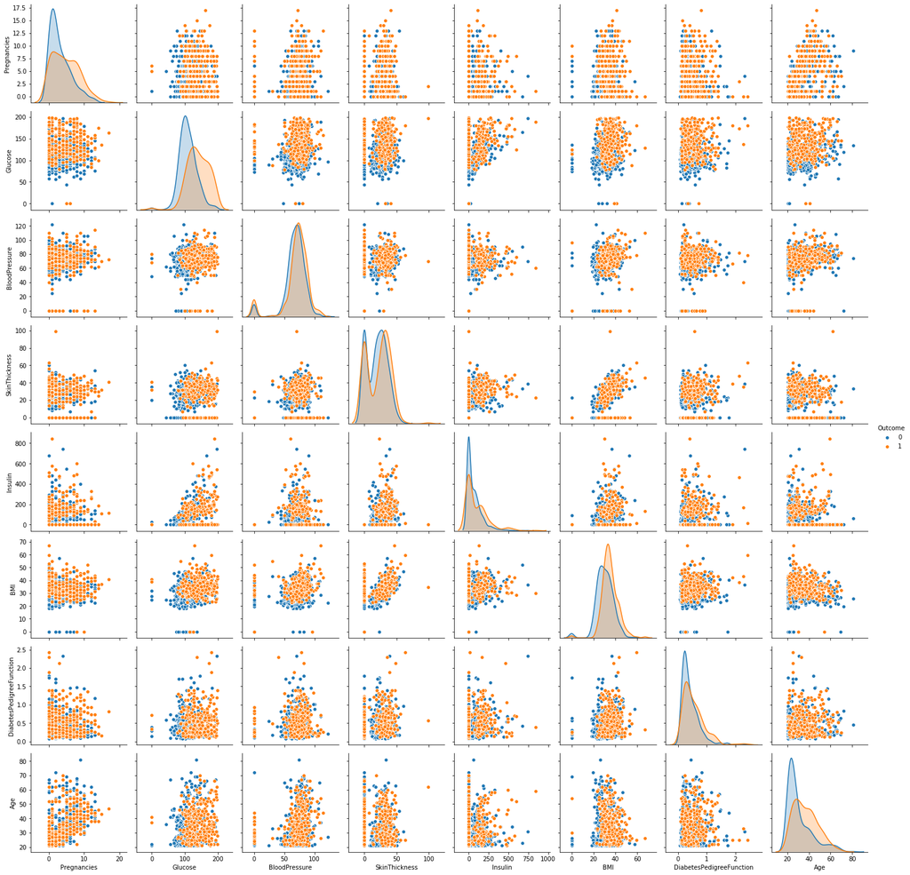

```python
# creating the pairplot
sns.pairplot(df, hue="Outcome")
```

### finding skewed independent variables

A skewness value of 0 in the output denotes a symmetrical distribution of values in particular row

A negative skewness value in the output indicates an asymmetry in the distribution corresponding to a particular row and the tail is larger towards the left hand side of the distribution.

A positive skewness value in the output indicates an asymmetry in the distribution corresponding to particular row and the tail is larger towards the right hand side of the distribution.

```python
df.skew()
```

```
Pregnancies                 0.901674
Glucose                     0.173754
BloodPressure              -1.843608
SkinThickness               0.109372
Insulin                     2.272251
BMI                        -0.428982
DiabetesPedigreeFunction    1.919911
Age                         1.129597
Outcome                     0.635017
dtype: float64
```

### Conclusion : There is least skewness in Glucose(0.173754) and skin thickness(0.109372)

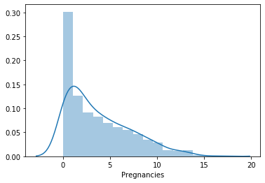

```python
sns.distplot(df["Pregnancies"])
```

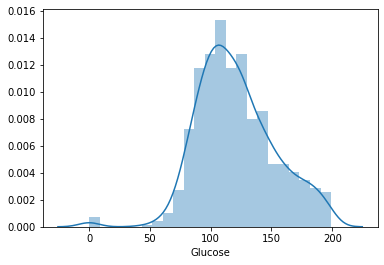

```python
sns.distplot(df["Glucose"])
```

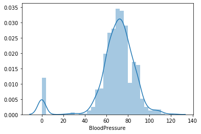

```python
sns.distplot(df["BloodPressure"])
```

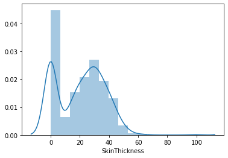

```python
sns.distplot(df["SkinThickness"])
```

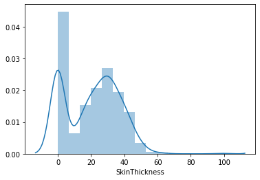

```python
sns.distplot(df["SkinThickness"])
```

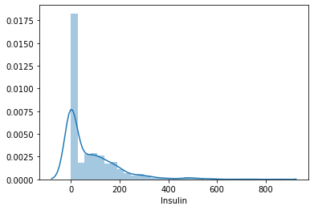

```python
sns.distplot(df["Insulin"])
```

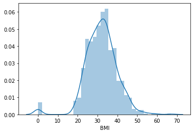

```python
sns.distplot(df["BMI"])
```

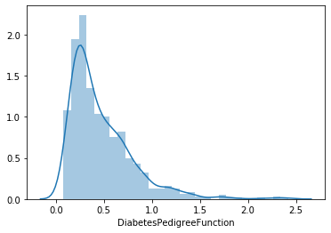

```python
sns.distplot(df["DiabetesPedigreeFunction"])
```

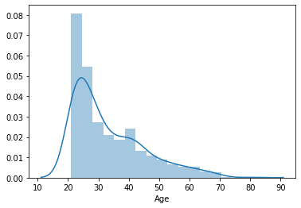

```python
sns.distplot(df["Age"])
```

### Checking Normal distribution of all variables using histogram

```
Outcome
0    [[AxesSubplot(0.125,0.670278;0.215278x0.209722...
1    [[AxesSubplot(0.125,0.670278;0.215278x0.209722...
dtype: object
```

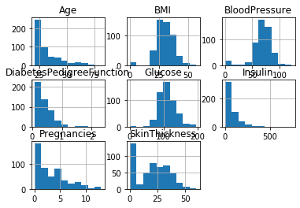

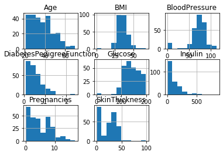

```python
df.groupby('Outcome').hist()
```

## Using Boxplot

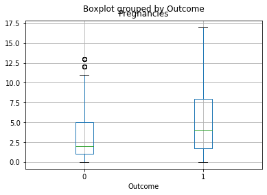

```python
df.boxplot(column="Pregnancies", by="Outcome")
```

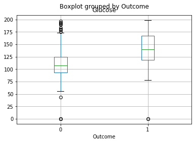

```python
df.boxplot(column="Glucose", by="Outcome")
```

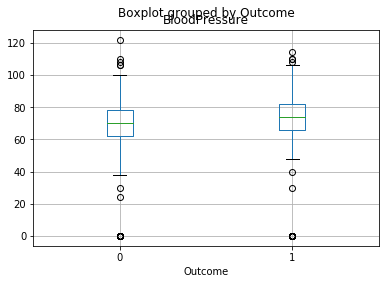

```python
df.boxplot(column="BloodPressure",by="Outcome")
```

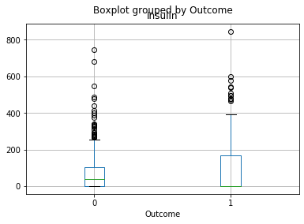

```python
df.boxplot(column="Insulin", by="Outcome")
```

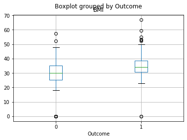

```python
df.boxplot(column="BMI", by="Outcome")
```

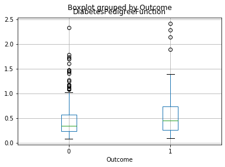

```python
df.boxplot(column="DiabetesPedigreeFunction", by="Outcome")
```

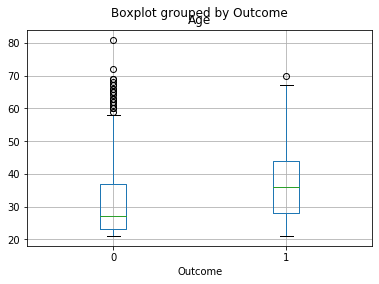

```python
df.boxplot(column="Age", by="Outcome")
```

```
array([<matplotlib.axes._subplots.AxesSubplot object at 0x000002114EC3B5C8>,
      dtype=object)
```

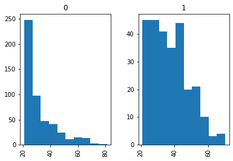

```python
df.hist(column="Age", by="Outcome")
```